# 게임 League Of Legend 승률 예측 모델

```python
import numpy as np
import pandas as pd
import scipy as sp
from scipy import stats

from matplotlib import pyplot as plt
import seaborn as sns
sns.set()

import statsmodels.formula.api as smf
import statsmodels.api as sm

%precision 3
%matplotlib inline

Cha_data = pd.read_csv('Challenger_Ranked_Games.csv')
Grm_data = pd.read_csv('GrandMaster_Ranked_games.csv')
Mas_data = pd.read_csv('Master_Ranked_Games.csv')
```

### 데이터 출처와 설명

https://www.kaggle.com/gyejr95/league-of-legends-challenger-ranked-games2020  
League Of Legneds High elo Ranked Games(2020)  
챌린저,그랜드마스터,마스터 티어 유저들의 2020년 게임 데이터

### 데이터 처리

다중공선성 문제 해결을 위해(blueKills,redDeath는 상관관계가 있음이 분명) RedTeam의 변수들을 제거하였음

```python
Challenger = Cha_data.drop(['redWins', 'redFirstBlood', 'redFirstTower',
       'redFirstBaron', 'redFirstDragon', 'redFirstInhibitor',
       'redWardPlaced', 'redWardkills', 'redKills', 'redDeath', 'redAssist',
       'redDragonKills', 'redBaronKills', 'redTowerKills', 'redInhibitorKills',
       'redChampionDamageDealt', 'redTotalGold', 'redTotalMinionKills',
       'redTotalLevel', 'redAvgLevel', 'redJungleMinionKills',
       'redKillingSpree', 'redTotalHeal', 'redObjectDamageDealt'], axis = 1)
GrandMaster = Grm_data.drop(['redWins', 'redFirstBlood', 'redFirstTower',
       'redFirstBaron', 'redFirstDragon', 'redFirstInhibitor',
       'redWardPlaced', 'redWardkills', 'redKills', 'redDeath', 'redAssist',
       'redDragonKills', 'redBaronKills', 'redTowerKills', 'redInhibitorKills',
       'redChampionDamageDealt', 'redTotalGold', 'redTotalMinionKills',
       'redTotalLevel', 'redAvgLevel', 'redJungleMinionKills',
       'redKillingSpree', 'redTotalHeal', 'redObjectDamageDealt'], axis = 1)
Master = Mas_data.drop(['redWins', 'redFirstBlood', 'redFirstTower',
       'redFirstBaron', 'redFirstDragon', 'redFirstInhibitor',
       'redDragonKills', 'redBaronKills', 'redTowerKills', 'redInhibitorKills',
       'redWardPlaced', 'redWardkills', 'redKills', 'redDeath', 'redAssist',
       'redChampionDamageDealt', 'redTotalGold', 'redTotalMinionKills',
       'redTotalLevel', 'redAvgLevel', 'redJungleMinionKills',
       'redKillingSpree', 'redTotalHeal', 'redObjectDamageDealt'], axis = 1)
Challenger = Challenger.drop(Challenger[Challenger['gameDuraton'] <= 300].index)
GrandMaster = GrandMaster.drop(GrandMaster[GrandMaster['gameDuraton'] <= 300].index)
Master = Master.drop(Master[Master['gameDuraton'] <= 300].index)
```

```python
df1 = pd.merge(Challenger, GrandMaster)
df2 = pd.merge(df1, Master)
df2
```

|  | gameId | gameDuraton | blueWins | blueFirstBlood | blueFirstTower | blueFirstBaron | blueFirstDragon | blueFirstInhibitor | blueDragonKills | blueBaronKills | ... | blueAssist | blueChampionDamageDealt | blueTotalGold | blueTotalMinionKills | blueTotalLevel | blueAvgLevel | blueJungleMinionKills | blueKillingSpree | blueTotalHeal | blueObjectDamageDealt |
| --- | --- | --- | --- | --- | --- | --- | --- | --- | --- | --- | --- | --- | --- | --- | --- | --- | --- | --- | --- | --- | --- |
| 0 | 4219545724 | 1313 | 0 | 0 | 1 | 0 | 0 | 0 | 0 | 0 | ... | 9 | 36087 | 35880 | 563 | 56 | 11.2 | 119 | 1 | 13059 | 26348 |
| 1 | 4219463634 | 1660 | 1 | 0 | 0 | 1 | 1 | 1 | 1 | 1 | ... | 61 | 64708 | 58214 | 651 | 74 | 14.8 | 209 | 7 | 37288 | 64577 |
| 2 | 4205778093 | 984 | 1 | 1 | 1 | 0 | 1 | 0 | 2 | 0 | ... | 34 | 45772 | 36545 | 402 | 53 | 10.6 | 102 | 6 | 14093 | 31303 |
| 3 | 4169807983 | 1109 | 1 | 0 | 1 | 0 | 1 | 0 | 2 | 0 | ... | 30 | 52628 | 37722 | 484 | 58 | 11.6 | 111 | 4 | 20715 | 38287 |
| 4 | 4158792026 | 1845 | 1 | 1 | 1 | 0 | 1 | 1 | 4 | 1 | ... | 58 | 84049 | 65775 | 690 | 79 | 15.8 | 221 | 9 | 26997 | 89993 |
| ... | ... | ... | ... | ... | ... | ... | ... | ... | ... | ... | ... | ... | ... | ... | ... | ... | ... | ... | ... | ... | ... |
| 10075 | 4167348313 | 2049 | 0 | 1 | 1 | 0 | 1 | 0 | 2 | 0 | ... | 35 | 108326 | 62122 | 766 | 79 | 15.8 | 181 | 8 | 20604 | 45077 |
| 10076 | 4190417319 | 1711 | 1 | 1 | 0 | 1 | 1 | 1 | 4 | 1 | ... | 41 | 86888 | 56699 | 607 | 73 | 14.6 | 183 | 9 | 46662 | 72302 |
| 10077 | 4139037171 | 1212 | 1 | 1 | 0 | 0 | 0 | 1 | 2 | 0 | ... | 28 | 42281 | 41367 | 509 | 58 | 11.6 | 118 | 5 | 14893 | 48971 |
| 10078 | 4087132870 | 1828 | 1 | 0 | 1 | 0 | 1 | 1 | 3 | 0 | ... | 35 | 74838 | 60024 | 781 | 74 | 14.8 | 214 | 6 | 43116 | 79940 |
| 10079 | 4110201724 | 1837 | 1 | 1 | 0 | 0 | 1 | 0 | 3 | 0 | ... | 66 | 93059 | 58160 | 640 | 76 | 15.2 | 168 | 7 | 75427 | 60486 |

10080 rows × 26 columns

### data의 열 확인

```python
df2.columns
```

```
Index(['gameId', 'gameDuraton', 'blueWins', 'blueFirstBlood', 'blueFirstTower',
       'blueFirstBaron', 'blueFirstDragon', 'blueFirstInhibitor',
       'blueDragonKills', 'blueBaronKills', 'blueTowerKills',
       'blueInhibitorKills', 'blueWardPlaced', 'blueWardkills', 'blueKills',
       'blueDeath', 'blueAssist', 'blueChampionDamageDealt', 'blueTotalGold',
       'blueTotalMinionKills', 'blueTotalLevel', 'blueAvgLevel',
       'blueJungleMinionKills', 'blueKillingSpree', 'blueTotalHeal',
       'blueObjectDamageDealt'],
      dtype='object')
```

### 변수가 1개인 로지스틱 회귀 모델을 만들고, AIC 값이 작은 순서대로 나열

```python
result = []

for x in ['blueFirstBlood', 'blueFirstTower',
       'blueFirstBaron', 'blueFirstDragon', 'blueFirstInhibitor',
       'blueDragonKills', 'blueBaronKills', 'blueTowerKills',
       'blueInhibitorKills', 'blueWardPlaced', 'blueWardkills', 'blueKills',
       'blueDeath', 'blueAssist', 'blueChampionDamageDealt', 'blueTotalGold',
       'blueTotalMinionKills', 'blueTotalLevel', 'blueAvgLevel',
       'blueJungleMinionKills', 'blueKillingSpree', 'blueTotalHeal',
       'blueObjectDamageDealt']:
    formula = f"blueWins ~ {x}"
    res = smf.glm(formula, data = df2, family=sm.families.Binomial()).fit()
    result.append((res.aic, formula))
```

```python
result.sort()
result
```

```
[(6977.036734498908, 'blueWins ~ blueTowerKills'),
 (9111.860453353718, 'blueWins ~ blueFirstInhibitor'),
 (9342.785186023753, 'blueWins ~ blueInhibitorKills'),
 (9705.63167421192, 'blueWins ~ blueObjectDamageDealt'),
 (10132.665357410051, 'blueWins ~ blueDeath'),
 (10287.501697102613, 'blueWins ~ blueKills'),
 (10723.316161023922, 'blueWins ~ blueDragonKills'),
 (10880.346148313218, 'blueWins ~ blueKillingSpree'),
 (11117.863825844388, 'blueWins ~ blueAssist'),
 (11800.988558014502, 'blueWins ~ blueFirstTower'),
 (12251.521112372393, 'blueWins ~ blueBaronKills'),
 (12280.021824752865, 'blueWins ~ blueFirstBaron'),
 (12929.066498527622, 'blueWins ~ blueTotalGold'),
 (13050.122618964057, 'blueWins ~ blueFirstDragon'),
 (13136.208230053488, 'blueWins ~ blueJungleMinionKills'),
 (13222.682595967151, 'blueWins ~ blueAvgLevel'),
 (13222.682595967151, 'blueWins ~ blueTotalLevel'),
 (13428.943576703263, 'blueWins ~ blueTotalHeal'),
 (13524.17081188308, 'blueWins ~ blueFirstBlood'),
 (13604.674148540907, 'blueWins ~ blueChampionDamageDealt'),
 (13875.940697793041, 'blueWins ~ blueTotalMinionKills'),
 (13886.633761398261, 'blueWins ~ blueWardkills'),
 (13950.916179292632, 'blueWins ~ blueWardPlaced')]
```

AIC가 가장 작은 독립변수부터 하나씩 추가하면서 예측 모델을 만듬(전진 선택법) 가장 단순한 회귀모형인 null model에서 출발하여 가장 중요한 변수들을 골라 차례대로 모형에 포함 시켜나가는 과정이지만, 23가지 변수를 모든 경우의 수를 따져가면서 선택할 수 없기에, 단일독립변수 회귀모델에서 AIC가 낮은 값부터 차례대로 추가한 모형들을 만들었다. 또한 로지스틱 회귀 독립변수는 여러 개 있어도 상관 없고, 연속형과 카테고리형이 섞여있어도 상관 없으므로 로지스틱 회귀 모델을 선택하였다.

```python
mod_null = smf.glm("blueWins ~ 1", data = df2,
    family=sm.families.Binomial()).fit()
mod_1= smf.glm(formula = "blueWins ~ blueTowerKills",
                  data = df2,
                  family=sm.families.Binomial()).fit()
mod_2= smf.glm(formula = "blueWins ~ blueTowerKills + blueFirstInhibitor",
                  data = df2,
                  family=sm.families.Binomial()).fit()
mod_3= smf.glm(formula = "blueWins ~ blueTowerKills + blueFirstInhibitor + blueInhibitorKills",
                  data = df2,
                  family=sm.families.Binomial()).fit()
mod_4= smf.glm(formula = "blueWins ~ blueTowerKills + blueFirstInhibitor + blueInhibitorKills + blueObjectDamageDealt",
                  data = df2,
                  family=sm.families.Binomial()).fit()
mod_5= smf.glm(formula = "blueWins ~ blueTowerKills + blueFirstInhibitor + blueInhibitorKills + blueObjectDamageDealt + blueDeath",
                  data = df2,
                  family=sm.families.Binomial()).fit()
mod_6= smf.glm(formula = "blueWins ~ blueTowerKills + blueFirstInhibitor + blueInhibitorKills + blueObjectDamageDealt + blueDeath + blueKills",
                  data = df2,
                  family=sm.families.Binomial()).fit()
mod_7= smf.glm(formula = "blueWins ~ blueTowerKills + blueFirstInhibitor + blueInhibitorKills + blueObjectDamageDealt + blueDeath + blueKills + blueDragonKills",
                  data = df2,
                  family=sm.families.Binomial()).fit()
mod_8 = smf.glm(formula = "blueWins ~ blueTowerKills + blueFirstInhibitor + blueInhibitorKills + blueObjectDamageDealt + blueDeath + blueKills + blueDragonKills + blueKillingSpree",
                  data = df2,
                  family=sm.families.Binomial()).fit()
```

```python
print(mod_null.aic.round(3))
print(mod_1.aic.round(3))
print(mod_2.aic.round(3))
print(mod_3.aic.round(3))
print(mod_4.aic.round(3))
print(mod_5.aic.round(3))
print(mod_6.aic.round(3))
print(mod_7.aic.round(3))
print(mod_8.aic.round(3))
```

```
13973.847
6977.037
6942.218
6848.411
6800.637
2858.101
1622.733
1617.499
1619.227
```

변수를 7개 지정한 모델에서 가장 낮은 AIC 값을 보이고 8개 지정하였을때보다 AIC 값이 더 작아 변수가 7개인 모델이 최적의 모델이라 판단 하였다. 또한 23개의 변수 중에서 7가지 변수를 선택하여 간단하고 과적합(오버피팅) 하지 않은 모델이라 판단하였다.

```python
mod_9 = smf.glm(formula = "blueWins ~ blueTowerKills + blueFirstInhibitor + blueInhibitorKills + blueObjectDamageDealt + blueDeath + blueKills + blueDragonKills + blueKillingSpree + blueAssist",
                  data = df2,
                  family=sm.families.Binomial()).fit()
mod_10 = smf.glm(formula = "blueWins ~ blueTowerKills + blueFirstInhibitor + blueInhibitorKills + blueObjectDamageDealt + blueDeath + blueKills + blueDragonKills + blueKillingSpree + blueAssist + blueFirstTower",
                  data = df2,
                  family=sm.families.Binomial()).fit()
mod_11 = smf.glm(formula = "blueWins ~ blueTowerKills + blueFirstInhibitor + blueInhibitorKills + blueObjectDamageDealt + blueDeath + blueKills + blueDragonKills + blueKillingSpree + blueAssist + blueFirstTower + blueBaronKills",
                  data = df2,
                  family=sm.families.Binomial()).fit()
print(mod_9.aic.round(3))
print(mod_10.aic.round(3))
print(mod_11.aic.round(3))
```

```
1600.835
1601.813
1562.201
```

변수가 9개 이상인 모델에서 변수가 늘어날수록 AIC가 낮아지는 경향을 보였으나, 이는 적합도는 높으나 예측 정확도가 낮을 가능성이 큰 과적합 모델일 가능성이 커 더이상의 변수를 추가하는 경우는 배제하고 모델을 설정하였다.

### 피어슨카이제곱통계량

```python
print(mod_5.pearson_chi2.round(3))
print(mod_6.pearson_chi2.round(3))
print(mod_7.pearson_chi2.round(3))
print(mod_8.pearson_chi2.round(3))
```

```
9287675.491
34664.655
34875.975
34803.842
```

### deviance

```python
print(mod_5.deviance.round(3))
print(mod_6.deviance.round(3))
print(mod_7.deviance.round(3))
print(mod_8.deviance.round(3))
```

```
2846.101
1608.733
1601.499
1601.227
```

피어슨 카이제곱통계량(피어슨 잔차의 제곱합)은 변수가 6개인 모델이 가장 작고 그 다음으로 8개인 모델, 그 다음으로 7개인 모델순이다.(흩어짐이 작은 순서) deviance는 변수가 6개인 모델이 가장 크고 변수가 7개인 모델과 8개인 모델이 거의 비슷하였다.(모델의 적합도를 평가하는 지표로 작을 수록 모델이 적합하다)

### 데이터 적용

```python
df2['predicted_win_1'] = np.where(mod_6.predict() >= 0.5, 1, 0).astype(np.int64)
df2['predicted_win_2'] = np.where(mod_7.predict() >= 0.5, 1, 0).astype(np.int64)
df2['predicted_win_3'] = np.where(mod_8.predict() >= 0.5, 1, 0).astype(np.int64)
new1 = df2[df2['blueWins'] != df2['predicted_win_1']]
new2 = df2[df2['blueWins'] != df2['predicted_win_2']]
new3 = df2[df2['blueWins'] != df2['predicted_win_3']]
```

```python
print(len(new1))
print(len(new2))
print(len(new3))
```

```
310
304
306
```

```python
(10800 - 304) / 10800
```

```
0.972
```

실제로 데이터를 적용해보니 예측이 틀린 샘플의 개수는 변수의 개수가 7개인 모델이 가장 적었다. 따라서 변수의 개수가 7개인 모델이 가장 적합하고 간단한 모델이라고 판단하였다.

### 선택된 모델 요약

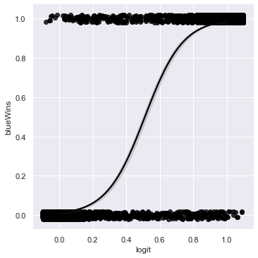

```python
df2['logit'] = mod_7.predict()
sns.lmplot(x = "logit", y = "blueWins",
           data = df2,
           logistic = True,
           scatter_kws = {"color": "black"},
           line_kws    = {"color": "black"},
           x_jitter = 0.1, y_jitter = 0.02)
```

```python
mod_7.summary()
```

Generalized Linear Model Regression Results

| Dep. Variable: | blueWins | No. Observations: | 10080 |
| --- | --- | --- | --- |
| Model: | GLM | Df Residuals: | 10072 |
| Model Family: | Binomial | Df Model: | 7 |
| Link Function: | logit | Scale: | 1.0000 |
| Method: | IRLS | Log-Likelihood: | -800.75 |
| Date: | Mon, 07 Jun 2021 | Deviance: | 1601.5 |
| Time: | 20:33:02 | Pearson chi2: | 3.49e+04 |
| No. Iterations: | 9 |  |  |
| Covariance Type: | nonrobust |  |  |

|  | coef | std err | z | P>\|z\| | [0.025 | 0.975] |
| --- | --- | --- | --- | --- | --- | --- |
| Intercept | -0.7340 | 0.223 | -3.284 | 0.001 | -1.172 | -0.296 |
| blueTowerKills | 0.7061 | 0.054 | 12.979 | 0.000 | 0.599 | 0.813 |
| blueFirstInhibitor | 0.0937 | 0.205 | 0.458 | 0.647 | -0.308 | 0.495 |
| blueInhibitorKills | 0.3934 | 0.139 | 2.831 | 0.005 | 0.121 | 0.666 |
| blueObjectDamageDealt | -1.955e-05 | 5.67e-06 | -3.448 | 0.001 | -3.07e-05 | -8.44e-06 |
| blueDeath | -0.4447 | 0.014 | -32.754 | 0.000 | -0.471 | -0.418 |
| blueKills | 0.3382 | 0.014 | 24.947 | 0.000 | 0.312 | 0.365 |
| blueDragonKills | 0.2003 | 0.075 | 2.685 | 0.007 | 0.054 | 0.347 |

각 변수간 승리와의 상관관계

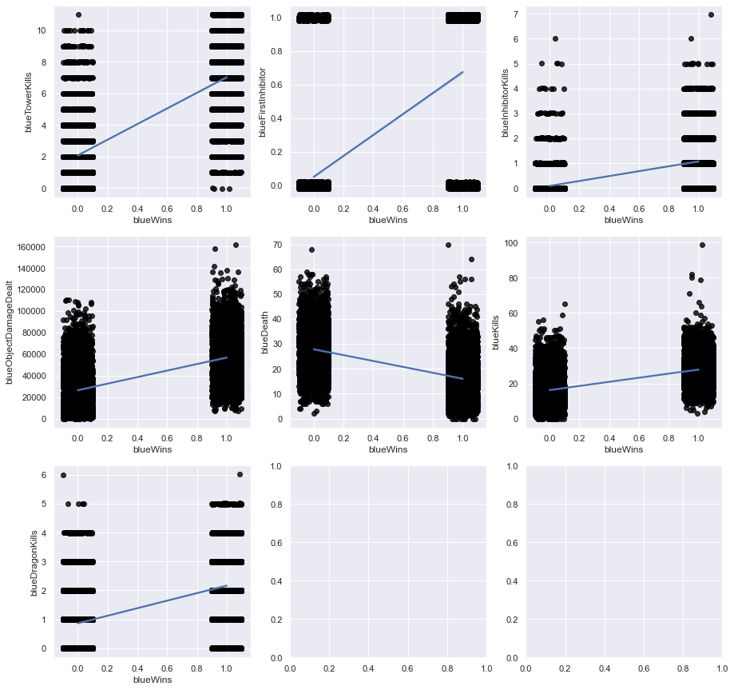

```python
fig, ax = plt.subplots(figsize = (15,15), ncols=3, nrows=3)
sns.regplot(x = "blueWins", y = "blueTowerKills", data = df2, scatter_kws = {"color": "black"},  x_jitter = 0.1, y_jitter = 0.02, ax = ax[0][0])
sns.regplot(x = "blueWins", y = "blueFirstInhibitor",data = df2,scatter_kws = {"color": "black"}, x_jitter = 0.1, y_jitter = 0.02, ax = ax[0][1])
sns.regplot(x = "blueWins", y = "blueInhibitorKills",data = df2,scatter_kws = {"color": "black"}, x_jitter = 0.1, y_jitter = 0.02, ax = ax[0][2])
sns.regplot(x = "blueWins", y = "blueObjectDamageDealt",data = df2,scatter_kws = {"color": "black"}, x_jitter = 0.1, y_jitter = 0.02, ax = ax[1][0])
sns.regplot(x = "blueWins", y = "blueDeath",data = df2,scatter_kws = {"color": "black"}, x_jitter = 0.1, y_jitter = 0.02, ax = ax[1][1])
sns.regplot(x = "blueWins", y = "blueKills",data = df2,scatter_kws = {"color": "black"}, x_jitter = 0.1, y_jitter = 0.02, ax = ax[1][2])
sns.regplot(x = "blueWins", y = "blueDragonKills",data = df2,scatter_kws = {"color": "black"}, x_jitter = 0.1, y_jitter = 0.02, ax = ax[2][0])
```

blueFirstInhibitor만 p 값이 0.647로 매우 큰 값이 나와서 blueFirstInhibitor 변수를 제외한 새로운 모델을 만들고 적용시켜 보았다.

```python
new_mod_7_1= smf.glm(formula = "blueWins ~ blueTowerKills + blueInhibitorKills + blueObjectDamageDealt + blueDeath + blueKills + blueDragonKills",
                  data = df2,
                  family=sm.families.Binomial()).fit()
df2['predicted_win_4'] = np.where(new_mod_7_1.predict() >= 0.5, 1, 0).astype(np.int64)
new4 = df2[df2['blueWins'] != df2['predicted_win_4']]
```

```python
new_mod_7_2 = smf.glm(formula = "blueWins ~ blueTowerKills + blueFirstInhibitor + blueInhibitorKills + blueObjectDamageDealt + blueDeath + blueKills",
                  data = df2,
                  family=sm.families.Binomial()).fit()
df2['predicted_win_5'] = np.where(new_mod_7_2.predict() >= 0.5, 1, 0).astype(np.int64)
new5 = df2[df2['blueWins'] != df2['predicted_win_5']]
```

두 변수 모두 제외한 모델을 만들어 보았다.

```python
new_mod_7_3 = smf.glm(formula = "blueWins ~ blueTowerKills + blueInhibitorKills + blueObjectDamageDealt + blueDeath + blueKills",
                  data = df2,
                  family=sm.families.Binomial()).fit()
df2['predicted_win_6'] = np.where(new_mod_7_3.predict() >= 0.5, 1, 0).astype(np.int64)
new6 = df2[df2['blueWins'] != df2['predicted_win_6']]
```

### 만든 모델 적용

```python
print(len(new4))
print(len(new5))
print(len(new6))
```

```
304
310
310
```

```python
print(mod_7.aic.round(3))
print(new_mod_7_1.aic.round(3))
print(new_mod_7_2.aic.round(3))
print(new_mod_7_3.aic.round(3))
```

```
1617.499
1615.708
1622.733
1620.845
```

```python
print(mod_7.pearson_chi2.round(3))
print(new_mod_7_1.pearson_chi2.round(3))
print(new_mod_7_2.pearson_chi2.round(3))
print(new_mod_7_3.pearson_chi2.round(3))
```

```
34875.975
35359.005
34664.655
35063.495
```

```python
print(mod_7.deviance.round(3))
print(new_mod_7_1.deviance.round(3))
print(new_mod_7_2.deviance.round(3))
print(new_mod_7_3.deviance.round(3))
```

```
1601.499
1601.708
1608.733
1608.845
```

p값이 높은 blueFirstInhibitor 변수를 제외한 새로운 변수 6개를 가진 새로운 모델이 AIC값이 낮고 deviance와 적중률이 차이가 없고, 변수가 더 적기 때문에 가장 적합한 모델 이라고 최종적으로 결정내렸다.

### 최종 선택된 모델

```python
new_mod_7_1.summary()
```

Generalized Linear Model Regression Results

| Dep. Variable: | blueWins | No. Observations: | 10080 |
| --- | --- | --- | --- |
| Model: | GLM | Df Residuals: | 10073 |
| Model Family: | Binomial | Df Model: | 6 |
| Link Function: | logit | Scale: | 1.0000 |
| Method: | IRLS | Log-Likelihood: | -800.85 |
| Date: | Mon, 07 Jun 2021 | Deviance: | 1601.7 |
| Time: | 20:37:01 | Pearson chi2: | 3.54e+04 |
| No. Iterations: | 9 |  |  |
| Covariance Type: | nonrobust |  |  |

|  | coef | std err | z | P>\|z\| | [0.025 | 0.975] |
| --- | --- | --- | --- | --- | --- | --- |
| Intercept | -0.7335 | 0.224 | -3.280 | 0.001 | -1.172 | -0.295 |
| blueTowerKills | 0.7111 | 0.053 | 13.341 | 0.000 | 0.607 | 0.816 |
| blueInhibitorKills | 0.4238 | 0.122 | 3.461 | 0.001 | 0.184 | 0.664 |
| blueObjectDamageDealt | -1.958e-05 | 5.67e-06 | -3.454 | 0.001 | -3.07e-05 | -8.47e-06 |
| blueDeath | -0.4453 | 0.014 | -32.921 | 0.000 | -0.472 | -0.419 |
| blueKills | 0.3385 | 0.014 | 24.993 | 0.000 | 0.312 | 0.365 |
| blueDragonKills | 0.1988 | 0.075 | 2.667 | 0.008 | 0.053 | 0.345 |

### 적중하지 못한 데이터는 왜 모델이 맞추지 못했을까?

모델이 맞추지 못한 데이터의 행들

```python
new4
```

|  | gameId | gameDuraton | blueWins | blueFirstBlood | blueFirstTower | blueFirstBaron | blueFirstDragon | blueFirstInhibitor | blueDragonKills | blueBaronKills | ... | blueAvgLevel | blueJungleMinionKills | blueKillingSpree | blueTotalHeal | blueObjectDamageDealt | predicted_win_1 | predicted_win_2 | predicted_win_3 | logit | predicted_win_4 |
| --- | --- | --- | --- | --- | --- | --- | --- | --- | --- | --- | --- | --- | --- | --- | --- | --- | --- | --- | --- | --- | --- |
| 32 | 4207361443 | 1838 | 1 | 0 | 0 | 1 | 1 | 1 | 2 | 1 | ... | 15.6 | 185 | 9 | 27065 | 90825 | 0 | 0 | 0 | 0.299510 | 0 |
| 50 | 4119100142 | 2085 | 0 | 1 | 1 | 1 | 1 | 1 | 4 | 1 | ... | 16.0 | 257 | 7 | 37891 | 88138 | 1 | 1 | 1 | 0.850605 | 1 |
| 58 | 4252594828 | 1401 | 1 | 1 | 0 | 1 | 1 | 1 | 3 | 1 | ... | 17.6 | 110 | 5 | 26592 | 84402 | 0 | 0 | 0 | 0.112926 | 0 |
| 65 | 4226087595 | 1693 | 0 | 0 | 0 | 0 | 0 | 1 | 2 | 0 | ... | 12.8 | 171 | 4 | 30718 | 50351 | 1 | 1 | 1 | 0.669708 | 1 |
| 94 | 4197206878 | 2381 | 1 | 0 | 0 | 1 | 1 | 1 | 3 | 1 | ... | 17.2 | 175 | 7 | 41235 | 67875 | 0 | 0 | 0 | 0.126684 | 0 |
| ... | ... | ... | ... | ... | ... | ... | ... | ... | ... | ... | ... | ... | ... | ... | ... | ... | ... | ... | ... | ... | ... |
| 9910 | 4204030558 | 2490 | 1 | 0 | 1 | 0 | 0 | 1 | 4 | 1 | ... | 17.6 | 311 | 8 | 71215 | 99005 | 0 | 0 | 0 | 0.012282 | 0 |
| 9948 | 4081874938 | 1299 | 1 | 1 | 1 | 0 | 0 | 0 | 2 | 0 | ... | 12.0 | 134 | 7 | 20898 | 35767 | 0 | 0 | 0 | 0.485462 | 0 |
| 9972 | 4185162735 | 2189 | 0 | 0 | 0 | 0 | 1 | 1 | 1 | 0 | ... | 15.8 | 216 | 4 | 35642 | 37513 | 1 | 1 | 1 | 0.567069 | 1 |
| 9981 | 4169959607 | 1793 | 0 | 1 | 1 | 0 | 1 | 1 | 3 | 0 | ... | 13.2 | 170 | 9 | 40957 | 54939 | 0 | 1 | 1 | 0.524889 | 1 |
| 10060 | 4195134075 | 1973 | 1 | 0 | 0 | 0 | 1 | 1 | 4 | 0 | ... | 15.8 | 202 | 9 | 50159 | 45895 | 0 | 0 | 0 | 0.419460 | 0 |

304 rows × 31 columns

모델이 맞추지 못한 데이터

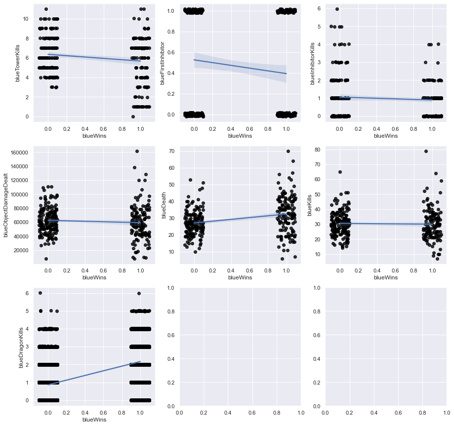

```python
fig, ax = plt.subplots(figsize = (15,15), ncols=3, nrows=3)
sns.regplot(x = "blueWins", y = "blueTowerKills",data = new4,scatter_kws = {"color": "black"}, x_jitter = 0.1, y_jitter = 0.02, ax = ax[0][0])
sns.regplot(x = "blueWins", y = "blueFirstInhibitor",data = new4,scatter_kws = {"color": "black"}, x_jitter = 0.1, y_jitter = 0.02, ax = ax[0][1])
sns.regplot(x = "blueWins", y = "blueInhibitorKills",data = new4,scatter_kws = {"color": "black"}, x_jitter = 0.1, y_jitter = 0.02, ax = ax[0][2])
sns.regplot(x = "blueWins", y = "blueObjectDamageDealt",data = new4,scatter_kws = {"color": "black"}, x_jitter = 0.1, y_jitter = 0.02, ax = ax[1][0])
sns.regplot(x = "blueWins", y = "blueDeath",data = new4,scatter_kws = {"color": "black"}, x_jitter = 0.1, y_jitter = 0.02, ax = ax[1][1])
sns.regplot(x = "blueWins", y = "blueKills",data = new4,scatter_kws = {"color": "black"}, x_jitter = 0.1, y_jitter = 0.02, ax = ax[1][2])
sns.regplot(x = "blueWins", y = "blueDragonKills",data = df2,scatter_kws = {"color": "black"}, x_jitter = 0.1, y_jitter = 0.02, ax = ax[2][0])
```

최적의 모델을 선택한 것과 같은 방식으로 데이터 적중에 실패한 행들의 데이터를 이용해서 새로운 모델을 만들고 최적의 모델과 차이점을 비교해 보았다

```python
result2 = []

for x in ['blueFirstBlood', 'blueFirstTower',
       'blueFirstBaron', 'blueFirstDragon', 'blueFirstInhibitor',
       'blueDragonKills', 'blueBaronKills', 'blueTowerKills',
       'blueInhibitorKills', 'blueWardPlaced', 'blueWardkills', 'blueKills',
       'blueDeath', 'blueAssist', 'blueChampionDamageDealt', 'blueTotalGold',
       'blueTotalMinionKills', 'blueTotalLevel', 'blueAvgLevel',
       'blueJungleMinionKills', 'blueKillingSpree', 'blueTotalHeal',
       'blueObjectDamageDealt']:
    formula = f"blueWins ~ {x}"
    res = smf.glm(formula, data = new2, family=sm.families.Binomial()).fit()
    result2.append((res.aic, formula))
```

```python
result2.sort()
result2
```

```
[(397.52902560550183, 'blueWins ~ blueDeath'),
 (411.1996703188092, 'blueWins ~ blueJungleMinionKills'),
 (412.0645277858166, 'blueWins ~ blueFirstBlood'),
 (414.0550915351678, 'blueWins ~ blueWardPlaced'),
 (414.42474888522565, 'blueWins ~ blueFirstTower'),
 (415.0853759070156, 'blueWins ~ blueTowerKills'),
 (416.7235016969411, 'blueWins ~ blueFirstInhibitor'),
 (417.833929999036, 'blueWins ~ blueWardkills'),
 (418.1264043630272, 'blueWins ~ blueBaronKills'),
 (418.2485972798489, 'blueWins ~ blueTotalMinionKills'),
 (419.56171194696617, 'blueWins ~ blueDragonKills'),
 (420.4276317695376, 'blueWins ~ blueObjectDamageDealt'),
 (420.4532897346194, 'blueWins ~ blueChampionDamageDealt'),
 (420.57755130115584, 'blueWins ~ blueInhibitorKills'),
 (421.2340773483498, 'blueWins ~ blueAssist'),
 (421.57250903523015, 'blueWins ~ blueTotalGold'),
 (421.64119120144665, 'blueWins ~ blueKillingSpree'),
 (421.8183237994634, 'blueWins ~ blueKills'),
 (421.86430394880676, 'blueWins ~ blueTotalHeal'),
 (421.8761075018249, 'blueWins ~ blueFirstDragon'),
 (422.0567852566769, 'blueWins ~ blueTotalLevel'),
 (422.05678525667696, 'blueWins ~ blueAvgLevel'),
 (422.05699710618137, 'blueWins ~ blueFirstBaron')]
```

```python
fail_null = smf.glm("blueWins ~ 1", data = new2,
    family=sm.families.Binomial()).fit()
fail_1 = smf.glm(formula = "blueWins ~ blueDeath",
                  data = new2,
                  family=sm.families.Binomial()).fit()
fail_2 = smf.glm(formula = "blueWins ~ blueDeath + blueJungleMinionKills",
                  data = new2,
                  family=sm.families.Binomial()).fit()
fail_3 = smf.glm(formula = "blueWins ~ blueDeath + blueJungleMinionKills + blueFirstBlood",
                  data = new2,
                  family=sm.families.Binomial()).fit()
fail_4 = smf.glm(formula = "blueWins ~ blueDeath + blueJungleMinionKills + blueFirstBlood + blueWardPlaced",
                  data = new2,
                  family=sm.families.Binomial()).fit()
fail_5 = smf.glm(formula = "blueWins ~ blueDeath + blueJungleMinionKills + blueFirstBlood + blueWardPlaced + blueFirstTower",
                  data = new2,
                  family=sm.families.Binomial()).fit()
fail_6 = smf.glm(formula = "blueWins ~ blueDeath + blueJungleMinionKills + blueFirstBlood + blueWardPlaced + blueFirstTower + blueTowerKills",
                  data = new2,
                  family=sm.families.Binomial()).fit()
fail_7 = smf.glm(formula = "blueWins ~ blueDeath + blueJungleMinionKills + blueFirstBlood + blueWardPlaced + blueFirstTower + blueTowerKills + blueFirstInhibitor",
                  data = new2,
                  family=sm.families.Binomial()).fit()
fail_8 = smf.glm(formula = "blueWins ~ blueDeath + blueJungleMinionKills + blueFirstBlood + blueWardPlaced + blueFirstTower + blueTowerKills + blueFirstInhibitor + blueWardkills",
                  data = new2,
                  family=sm.families.Binomial()).fit()
```

```python
print(fail_null.aic.round(3))
print(fail_1.aic.round(3))
print(fail_2.aic.round(3))
print(fail_3.aic.round(3))
print(fail_4.aic.round(3))
print(fail_5.aic.round(3))
print(fail_6.aic.round(3))
print(fail_7.aic.round(3))
print(fail_8.aic.round(3))
```

```
420.059
397.529
373.707
366.91
367.198
367.505
343.038
343.497
344.997
```

```python
fail_6.summary()
```

Generalized Linear Model Regression Results

| Dep. Variable: | blueWins | No. Observations: | 304 |
| --- | --- | --- | --- |
| Model: | GLM | Df Residuals: | 297 |
| Model Family: | Binomial | Df Model: | 6 |
| Link Function: | logit | Scale: | 1.0000 |
| Method: | IRLS | Log-Likelihood: | -164.52 |
| Date: | Mon, 07 Jun 2021 | Deviance: | 329.04 |
| Time: | 20:37:49 | Pearson chi2: | 589. |
| No. Iterations: | 5 |  |  |
| Covariance Type: | nonrobust |  |  |

|  | coef | std err | z | P>\|z\| | [0.025 | 0.975] |
| --- | --- | --- | --- | --- | --- | --- |
| Intercept | 0.2567 | 0.652 | 0.394 | 0.694 | -1.020 | 1.534 |
| blueDeath | 0.1563 | 0.024 | 6.513 | 0.000 | 0.109 | 0.203 |
| blueJungleMinionKills | -0.0068 | 0.004 | -1.712 | 0.087 | -0.014 | 0.001 |
| blueFirstBlood | -0.7767 | 0.274 | -2.840 | 0.005 | -1.313 | -0.241 |
| blueWardPlaced | -0.0059 | 0.007 | -0.871 | 0.384 | -0.019 | 0.007 |
| blueFirstTower | -0.1928 | 0.275 | -0.701 | 0.484 | -0.732 | 0.347 |
| blueTowerKills | -0.4560 | 0.095 | -4.826 | 0.000 | -0.641 | -0.271 |

예측 실패 기준 모델

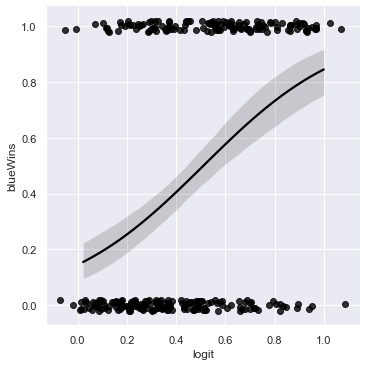

```python
new4['logit'] = fail_6.predict()
sns.lmplot(x = "logit", y = "blueWins",
           data = new4,
           logistic = True,
           scatter_kws = {"color": "black"},
           line_kws    = {"color": "black"},
           x_jitter = 0.1, y_jitter = 0.02)
```

로지스틱 회귀 모델이 불완전한 걸 볼 수 있다.

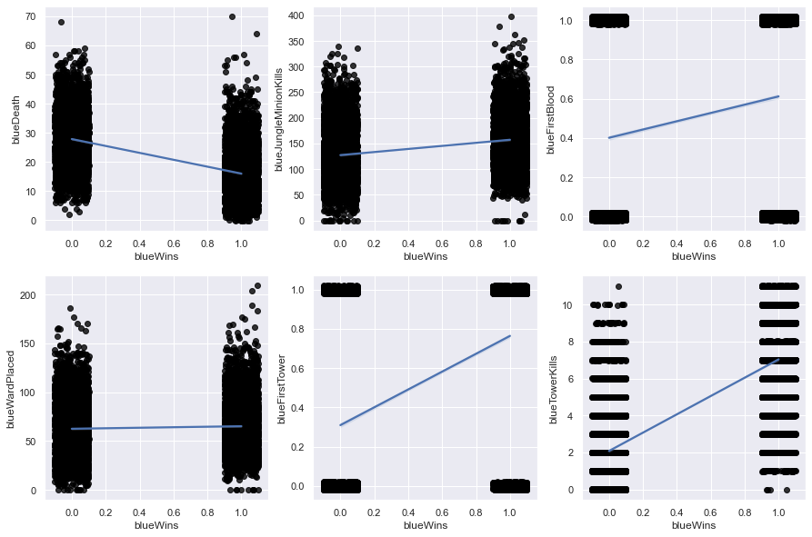

```python
fig, ax = plt.subplots(figsize = (15,10), ncols=3, nrows=2)
sns.regplot(x = "blueWins", y = "blueDeath",data = df2,scatter_kws = {"color": "black"}, x_jitter = 0.1, y_jitter = 0.02, ax = ax[0][0])
sns.regplot(x = "blueWins", y = "blueJungleMinionKills",data = df2,scatter_kws = {"color": "black"}, x_jitter = 0.1, y_jitter = 0.02, ax = ax[0][1])
sns.regplot(x = "blueWins", y = "blueFirstBlood",data = df2,scatter_kws = {"color": "black"}, x_jitter = 0.1, y_jitter = 0.02, ax = ax[0][2])
sns.regplot(x = "blueWins", y = "blueWardPlaced",data = df2,scatter_kws = {"color": "black"}, x_jitter = 0.1, y_jitter = 0.02, ax = ax[1][0])
sns.regplot(x = "blueWins", y = "blueFirstTower",data = df2,scatter_kws = {"color": "black"}, x_jitter = 0.1, y_jitter = 0.02, ax = ax[1][1])
sns.regplot(x = "blueWins", y = "blueTowerKills",data = df2,scatter_kws = {"color": "black"}, x_jitter = 0.1, y_jitter = 0.02, ax = ax[1][2])
```

```python
all_fail_mod = smf.glm(formula = "blueWins ~ blueDeath + blueJungleMinionKills + blueFirstBlood + blueWardPlaced + blueFirstTower + blueTowerKills",
                  data = df2,
                  family=sm.families.Binomial()).fit()
df2['fail_predicted_win'] = np.where(all_fail_mod.predict() >= 0.5, 1, 0).astype(np.int64)
new_fail = df2[df2['blueWins'] != df2['fail_predicted_win']]
len(new_fail)
```

```
521
```

```python
all_fail_mod.summary()
```

Generalized Linear Model Regression Results

| Dep. Variable: | blueWins | No. Observations: | 10080 |
| --- | --- | --- | --- |
| Model: | GLM | Df Residuals: | 10073 |
| Model Family: | Binomial | Df Model: | 6 |
| Link Function: | logit | Scale: | 1.0000 |
| Method: | IRLS | Log-Likelihood: | -1433.6 |
| Date: | Mon, 07 Jun 2021 | Deviance: | 2867.1 |
| Time: | 20:13:02 | Pearson chi2: | 3.16e+05 |
| No. Iterations: | 8 |  |  |
| Covariance Type: | nonrobust |  |  |

|  | coef | std err | z | P>\|z\| | [0.025 | 0.975] |
| --- | --- | --- | --- | --- | --- | --- |
| Intercept | 1.3457 | 0.166 | 8.102 | 0.000 | 1.020 | 1.671 |
| blueDeath | -0.2746 | 0.008 | -32.817 | 0.000 | -0.291 | -0.258 |
| blueJungleMinionKills | 0.0001 | 0.002 | 0.074 | 0.941 | -0.003 | 0.004 |
| blueFirstBlood | 0.1663 | 0.099 | 1.674 | 0.094 | -0.028 | 0.361 |
| blueWardPlaced | -0.0173 | 0.003 | -5.396 | 0.000 | -0.024 | -0.011 |
| blueFirstTower | -0.0467 | 0.104 | -0.449 | 0.654 | -0.251 | 0.157 |
| blueTowerKills | 1.3411 | 0.038 | 35.523 | 0.000 | 1.267 | 1.415 |

적중하지 못한 행들을 이용해 만든 모델을 전체데이터에 적용시키니 217개의 데이터를 더 최적의 모델보다 맞추지 못했으며, summary를 이용해서 모델을 분석해보니 blueJungleMinionKills, blueFirstTower, blueFirstBlood와 같은 3가지 변수가 우연히 나왔기(p 값이 0.05보다 큼) 때문에 이런 차이가 나타난 것으로 판단된다.

### 모델을 새로운 데이터에 적용시켜 보자!

2020 시즌 데이터를 이용해 만든 데이터를 2021 시즌 데이터를 롤 API를 이용해 구해온 뒤, 만든 모델을 적용시켜 보았다. 새로운 데이터를 구한 코드는 아래와 같다

```python
import requests
import pandas as pd
import re
import scipy as sp
import numpy as np
from scipy import stats
from matplotlib import pyplot as plt
import seaborn as sns
import statsmodels.formula.api as smf
import statsmodels.api as sm
from itertools import chain, combinations
import time
```

api key 활용해서 챌린저 sommonerld 들고오기

```python
api_key = 'RGAPI-c1cb007a-c35f-4bf1-9257-c018fd3c8313'

tier = '/RANKED_SOLO_5x5'
url_ch_league = "https://kr.api.riotgames.com/lol/league/v4/challengerleagues/by-queue" + tier + '?api_key=' + api_key
r = requests.get(url_ch_league)
```

```python
ch_league = r.json()
ch_league = ch_league['entries']
tier_name = []
for i in range(len(ch_league)) :
    tier_name.append(ch_league[i]['summonerId'])
len(tier_name)
```

```
300
```

```python
parsed_data_all_id = []
```

sommonerId 활용해서 유저별 accountId 들고오기(게임 데이터 분석을 위해서는 accountId 가 필요함.)

```python
for j in range(len(tier_name)) :
    all_id = 'https://kr.api.riotgames.com/lol/summoner/v4/summoners/' + tier_name[j] + '?api_key=' + api_key
    all_id2 = requests.get(all_id)
    if (all_id2.status_code != 200) :
        while (1):
            if(all_id2.status_code != 200) :
                time.sleep(10)
                all_id2 = requests.get(all_id)
            elif(all_id2.status_code == 200) :
                break
    parsed_data_all_id.append(all_id2.json()['accountId'])
```

ccountId 활용해서 최근 100게임의 matchlist 가져오기

```python
match_list_all = []
for i in parsed_data_all_id :
    match = 'https://kr.api.riotgames.com/lol/match/v4/matchlists/by-account/' + i + '?api_key=' + api_key
    all_match = requests.get(match)
    if (all_match.status_code != 200) :
        while (1):
            if(all_match.status_code != 200) :
                time.sleep(10)
                all_match = requests.get(match)
            elif(all_match.status_code == 200) :
                break
    match_list = all_match.json()
    for j in range(len(match_list['matches'])):
        match_list_all.append(match_list['matches'][j]['gameId'])
```

matchlist 활용해서 경기 데이터 가져오기

```python
def df_maker(test) :
    test1 = pd.DataFrame(test['teams'])
    test1 = test1.drop([1])
    tmp = pd.Series(test['participants'][0]['stats'])
    for i in range(1, 5):
        tmp = tmp + pd.Series(test['participants'][i]['stats']).iloc[9:51]
    tmp = pd.DataFrame(tmp).transpose()
    tmp = tmp.dropna(axis=1)
    return pd.merge(tmp, test1)
```

```python
df3_season13 = pd.DataFrame()

match = 'https://kr.api.riotgames.com/lol/match/v4/matches/' + str(match_list_all[0]) + '?api_key=' + api_key

all_match = requests.get(match)
test = all_match.json()
df3_season13 = df_maker(test)
```

```python
for j in range(1, len(match_list_all)):
    match = 'https://kr.api.riotgames.com/lol/match/v4/matches/' + str(match_list_all[j]) + '?api_key=' + api_key
    all_match = requests.get(match)
    if (all_match.status_code != 200) :
        print(all_match.status_code)
        while (1):
            if(all_match.status_code != 200) :
                time.sleep(10)
                all_match = requests.get(match)
            elif(all_match.status_code == 200) :
                break
    match_data = all_match.json()
    df3_season13 = pd.concat([df3_season13, df_maker(match_data)])
```

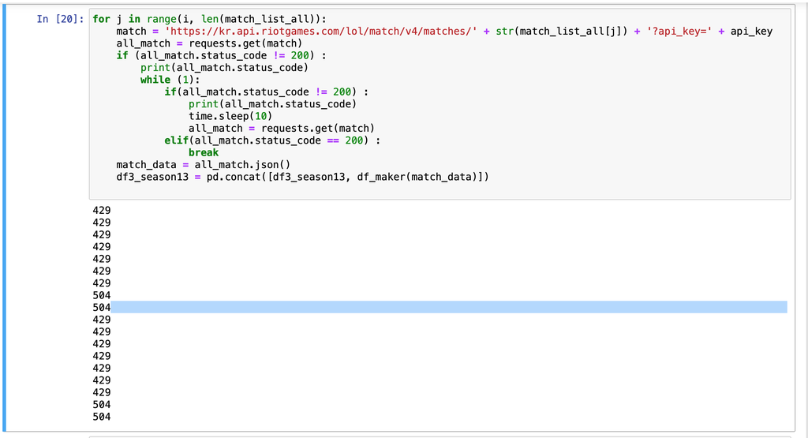

```python
from IPython.display import Image
Image("screenshot.png")
```

코드 실행 시간이 너무 오래걸려서 사진으로 대체하였습니다.

```python
df3_season13.to_excel('game_data.xlsx')
```

완성된 13시즌 데이터가 모델에 적영될 수 있도록 정리

```python
data = pd.read_excel('game_data.xlsx')
```

```python
data = data.dropna(axis=1).drop(['Unnamed: 0'], axis=1)[['win', 'towerKills', 'firstInhibitor', 'inhibitorKills', 'damageDealtToObjectives', 'deaths', 'kills', 'dragonKills']]
```

```python
data.rename(columns = {'win' : 'blueWins', 'towerKills' : 'blueTowerKills', 'firstInhibitor' : 'blueFirstInhibitor', 'inhibitorKills' : 'blueInhibitorKills', 'damageDealtToObjectives' : 'blueObjectDamageDealt', 'deaths' : 'blueDeath', 'kills': 'blueKills'}, inplace=True)
```

```python
data.blueWins = np.where(data.blueWins == 'Win', 1, 0)
data.blueFirstInhibitor = np.where(data.blueFirstInhibitor == True, 1, 0)
```

```python
data.to_csv('game_data_season13.csv')
```

### test 데이터 받아오기

```python
test = pd.read_csv('game_data_season13.csv')
```

test 데이터 확인

```python
test.head()
```

[output not shown]

```python
test.columns
```

```
Index(['Unnamed: 0', 'blueWins', 'blueTowerKills', 'blueFirstInhibitor',
       'blueInhibitorKills', 'blueObjectDamageDealt', 'blueDeath', 'blueKills',
       'blueDragonKills'],
      dtype='object')
```

앞에서 선택한 최적의 모델을 바탕으로 모델 만들기

```python
test_mod = smf.glm(formula = "blueWins ~ blueTowerKills + blueInhibitorKills + blueObjectDamageDealt + blueDeath + blueKills + blueDragonKills",
                  data = test,
                  family=sm.families.Binomial()).fit()
```

```python
test['test_win'] = np.where(test_mod.predict() >= 0.5, 1, 0).astype(np.int64)
test_data = test[test['blueWins'] != test['test_win']]
len(test_data)
```

```
530
```

13시즌 데이터 모델 적용

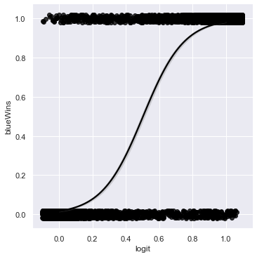

```python
test['logit'] = test_mod.predict()
sns.lmplot(x = "logit", y = "blueWins",
           data = test,
           logistic = True,
           scatter_kws = {"color": "black"},
           line_kws    = {"color": "black"},
           x_jitter = 0.1, y_jitter = 0.02)
```

변수 7개인 모델과 비교하기

```python
test_mod_2 = smf.glm(formula = "blueWins ~ blueTowerKills + blueFirstInhibitor + blueInhibitorKills + blueObjectDamageDealt + blueDeath + blueKills + blueDragonKills",
                  data = test,
                  family=sm.families.Binomial()).fit()
test['test_win_2'] = np.where(test_mod_2.predict() >= 0.5, 1, 0).astype(np.int64)
test_data_2 = test[test['blueWins'] != test['test_win_2']]
len(test_data_2)
```

```
531
```

13시즌 데이터 모델 적용

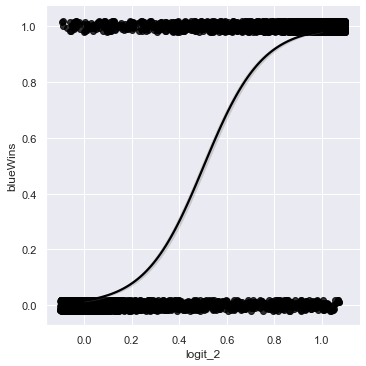

```python
test['logit_2'] = test_mod_2.predict()
sns.lmplot(x = "logit_2", y = "blueWins",
           data = test,
           logistic = True,
           scatter_kws = {"color": "black"},
           line_kws    = {"color": "black"},
           x_jitter = 0.1, y_jitter = 0.02)
```

```python
print(test_mod.aic.round(3))
print(test_mod_2.aic.round(3))
```

```
3068.889
3069.706
```

```python
print(test_mod.pearson_chi2.round(3))
print(test_mod_2.pearson_chi2.round(3))
```

```
19944.502
19806.712
```

```python
print(test_mod.deviance.round(3))
print(test_mod_2.deviance.round(3))
```

```
3054.889
3053.706
```

```python
(len(test) - len(test_data))/len(test)
```

```
0.958
```

선택한 모델의 적중률

### 만든 모델의 정보

```python
test_mod.summary()
```

Generalized Linear Model Regression Results

| Dep. Variable: | blueWins | No. Observations: | 12690 |
| --- | --- | --- | --- |
| Model: | GLM | Df Residuals: | 12683 |
| Model Family: | Binomial | Df Model: | 6 |
| Link Function: | logit | Scale: | 1.0000 |
| Method: | IRLS | Log-Likelihood: | -1527.4 |
| Date: | Mon, 07 Jun 2021 | Deviance: | 3054.9 |
| Time: | 20:21:42 | Pearson chi2: | 1.99e+04 |
| No. Iterations: | 8 |  |  |
| Covariance Type: | nonrobust |  |  |

|  | coef | std err | z | P>\|z\| | [0.025 | 0.975] |
| --- | --- | --- | --- | --- | --- | --- |
| Intercept | -0.1084 | 0.135 | -0.801 | 0.423 | -0.374 | 0.157 |
| blueTowerKills | 0.6664 | 0.042 | 16.020 | 0.000 | 0.585 | 0.748 |
| blueInhibitorKills | 0.8623 | 0.092 | 9.363 | 0.000 | 0.682 | 1.043 |
| blueObjectDamageDealt | -4.035e-05 | 4.24e-06 | -9.513 | 0.000 | -4.87e-05 | -3.2e-05 |
| blueDeath | -0.3410 | 0.008 | -42.677 | 0.000 | -0.357 | -0.325 |
| blueKills | 0.2841 | 0.008 | 36.135 | 0.000 | 0.269 | 0.300 |
| blueDragonKills | -0.0157 | 0.067 | -0.235 | 0.814 | -0.146 | 0.115 |

의미가 없는 행동이긴 하지만, blueDragonKills 가 p 값이 0.814로 크게 나와서 앞에서 train 데이터에 BlueDragonKills 변수를 제외한 모델을 만들어 보았었고, 이 변수를 제외한 모델은 train 데이터에서는 성능이 좋지 않았다. test 데이터는 train 데이터로 예측 할 수 없으므로 이런 변수가 나오는건 예측할 수 없었다.